# Risk Factor Analysis

## Outcome Variable

**Outcome Variable:** ever_co

## Predictor Variables

**Intervention Variable:** parity

**Adjustment Set:**

- arm
- W_mage
- meducyrs
- feducyrs
- hhwealth_quart
- W_mhtcm
- vagbrth
- W_nrooms
- impsan
- delta_W_mage
- delta_meducyrs
- delta_feducyrs
- delta_hhwealth_quart
- delta_W_mhtcm
- delta_vagbrth
- delta_W_nrooms
- delta_impsan

## Stratifying Variables

The analysis was stratified on these variable(s):

- agecat
- studyid
- country

## Data Summary

| agecat | studyid | country | parity | ever_co | n_cell | n |
| --- | --- | --- | --- | --- | --- | --- |
| 0-24 months | ki1000304b-SAS-CompFeed | INDIA | 1 | 0 | 359 | 1513 |
| 0-24 months | ki1000304b-SAS-CompFeed | INDIA | 1 | 1 | 89 | 1513 |
| 0-24 months | ki1000304b-SAS-CompFeed | INDIA | 2 | 0 | 285 | 1513 |
| 0-24 months | ki1000304b-SAS-CompFeed | INDIA | 2 | 1 | 69 | 1513 |
| 0-24 months | ki1000304b-SAS-CompFeed | INDIA | 3+ | 0 | 518 | 1513 |
| 0-24 months | ki1000304b-SAS-CompFeed | INDIA | 3+ | 1 | 193 | 1513 |
| 0-24 months | ki1000304b-SAS-FoodSuppl | INDIA | 1 | 0 | 57 | 397 |
| 0-24 months | ki1000304b-SAS-FoodSuppl | INDIA | 1 | 1 | 20 | 397 |
| 0-24 months | ki1000304b-SAS-FoodSuppl | INDIA | 2 | 0 | 55 | 397 |
| 0-24 months | ki1000304b-SAS-FoodSuppl | INDIA | 2 | 1 | 37 | 397 |
| 0-24 months | ki1000304b-SAS-FoodSuppl | INDIA | 3+ | 0 | 134 | 397 |
| 0-24 months | ki1000304b-SAS-FoodSuppl | INDIA | 3+ | 1 | 94 | 397 |
| 0-24 months | ki1017093b-PROVIDE | BANGLADESH | 1 | 0 | 232 | 700 |
| 0-24 months | ki1017093b-PROVIDE | BANGLADESH | 1 | 1 | 39 | 700 |
| 0-24 months | ki1017093b-PROVIDE | BANGLADESH | 2 | 0 | 217 | 700 |
| 0-24 months | ki1017093b-PROVIDE | BANGLADESH | 2 | 1 | 27 | 700 |
| 0-24 months | ki1017093b-PROVIDE | BANGLADESH | 3+ | 0 | 161 | 700 |
| 0-24 months | ki1017093b-PROVIDE | BANGLADESH | 3+ | 1 | 24 | 700 |
| 0-24 months | ki1066203-TanzaniaChild2 | TANZANIA, UNITED REPUBLIC OF | 1 | 0 | 783 | 2357 |
| 0-24 months | ki1066203-TanzaniaChild2 | TANZANIA, UNITED REPUBLIC OF | 1 | 1 | 38 | 2357 |
| 0-24 months | ki1066203-TanzaniaChild2 | TANZANIA, UNITED REPUBLIC OF | 2 | 0 | 732 | 2357 |
| 0-24 months | ki1066203-TanzaniaChild2 | TANZANIA, UNITED REPUBLIC OF | 2 | 1 | 39 | 2357 |
| 0-24 months | ki1066203-TanzaniaChild2 | TANZANIA, UNITED REPUBLIC OF | 3+ | 0 | 724 | 2357 |
| 0-24 months | ki1066203-TanzaniaChild2 | TANZANIA, UNITED REPUBLIC OF | 3+ | 1 | 41 | 2357 |
| 0-24 months | ki1101329-Keneba | GAMBIA | 1 | 0 | 212 | 1988 |
| 0-24 months | ki1101329-Keneba | GAMBIA | 1 | 1 | 28 | 1988 |
| 0-24 months | ki1101329-Keneba | GAMBIA | 2 | 0 | 193 | 1988 |
| 0-24 months | ki1101329-Keneba | GAMBIA | 2 | 1 | 21 | 1988 |
| 0-24 months | ki1101329-Keneba | GAMBIA | 3+ | 0 | 1255 | 1988 |
| 0-24 months | ki1101329-Keneba | GAMBIA | 3+ | 1 | 279 | 1988 |

[output cut: 168 more lines]

The following strata were considered:

- agecat: 0-24 months, studyid: ki1000304b-SAS-CompFeed, country: INDIA
- agecat: 0-24 months, studyid: ki1000304b-SAS-FoodSuppl, country: INDIA
- agecat: 0-24 months, studyid: ki1017093b-PROVIDE, country: BANGLADESH
- agecat: 0-24 months, studyid: ki1066203-TanzaniaChild2, country: TANZANIA, UNITED REPUBLIC OF
- agecat: 0-24 months, studyid: ki1101329-Keneba, country: GAMBIA
- agecat: 0-24 months, studyid: ki1113344-GMS-Nepal, country: NEPAL
- agecat: 0-24 months, studyid: ki1126311-ZVITAMBO, country: ZIMBABWE
- agecat: 0-24 months, studyid: ki1135781-COHORTS, country: GUATEMALA
- agecat: 0-24 months, studyid: ki1135781-COHORTS, country: INDIA
- agecat: 0-24 months, studyid: ki1135781-COHORTS, country: PHILIPPINES
- agecat: 0-24 months, studyid: kiGH5241-JiVitA-3, country: BANGLADESH
- agecat: 0-6 months, studyid: ki1000304b-SAS-CompFeed, country: INDIA
- agecat: 0-6 months, studyid: ki1000304b-SAS-FoodSuppl, country: INDIA
- agecat: 0-6 months, studyid: ki1017093b-PROVIDE, country: BANGLADESH
- agecat: 0-6 months, studyid: ki1066203-TanzaniaChild2, country: TANZANIA, UNITED REPUBLIC OF
- agecat: 0-6 months, studyid: ki1101329-Keneba, country: GAMBIA
- agecat: 0-6 months, studyid: ki1113344-GMS-Nepal, country: NEPAL
- agecat: 0-6 months, studyid: ki1126311-ZVITAMBO, country: ZIMBABWE
- agecat: 0-6 months, studyid: ki1135781-COHORTS, country: GUATEMALA
- agecat: 0-6 months, studyid: ki1135781-COHORTS, country: INDIA
- agecat: 0-6 months, studyid: ki1135781-COHORTS, country: PHILIPPINES
- agecat: 0-6 months, studyid: kiGH5241-JiVitA-3, country: BANGLADESH
- agecat: 6-24 months, studyid: ki1000304b-SAS-CompFeed, country: INDIA
- agecat: 6-24 months, studyid: ki1000304b-SAS-FoodSuppl, country: INDIA
- agecat: 6-24 months, studyid: ki1017093b-PROVIDE, country: BANGLADESH
- agecat: 6-24 months, studyid: ki1066203-TanzaniaChild2, country: TANZANIA, UNITED REPUBLIC OF
- agecat: 6-24 months, studyid: ki1101329-Keneba, country: GAMBIA
- agecat: 6-24 months, studyid: ki1113344-GMS-Nepal, country: NEPAL
- agecat: 6-24 months, studyid: ki1126311-ZVITAMBO, country: ZIMBABWE
- agecat: 6-24 months, studyid: ki1135781-COHORTS, country: GUATEMALA
- agecat: 6-24 months, studyid: ki1135781-COHORTS, country: INDIA
- agecat: 6-24 months, studyid: ki1135781-COHORTS, country: PHILIPPINES
- agecat: 6-24 months, studyid: kiGH5241-JiVitA-3, country: BANGLADESH

### Dropped Strata

Some strata were dropped due to rare outcomes:

- agecat: 0-6 months, studyid: ki1101329-Keneba, country: GAMBIA
- agecat: 0-6 months, studyid: ki1135781-COHORTS, country: GUATEMALA

## Methods Detail

We’re interested in the causal parameters $E[Y_a]$ for all values of $a \in \mathcal{A}$. These parameters represent the mean outcome if, possibly contrary to fact, we intervened to set all units to have $A=a$. Under the randomization and positivity assumptions, these are identified by the statistical parameters $\psi_a=E_W[E_{Y|A,W}(Y|A=a,W)]$. In addition, we’re interested in the mean of $Y$, $E[Y]$ under no intervention (the observed mean). We will estimate these parameters by using SuperLearner to fit the relevant likelihood factors – $E_{Y|A,W}(Y|A=a,W)$ and $p(A=a|W)$, and then updating our likelihood fit using a joint TMLE.

For unadjusted analyses ($W=\{\}$), initial likelihoods were estimated using Lrnr_glm to estimate the simple $E(Y|A)$ and Lrnr_mean to estimate $p(A)$. For adjusted analyses, a small library containing Lrnr_glmnet, Lrnr_xgboost, and Lrnr_mean was used.

Having estimated these parameters, we will then use the delta method to estimate relative risks and attributable risks relative to a prespecified baseline level of $A$.

# Results Detail

## Results Plots

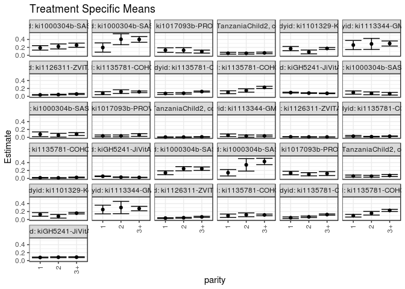

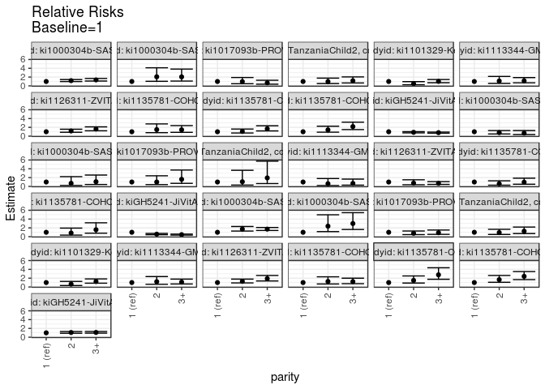

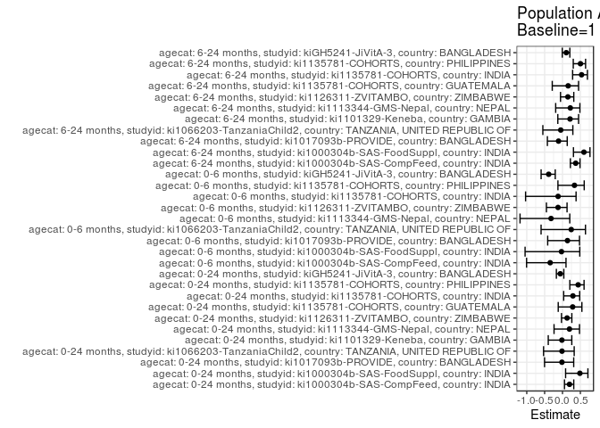

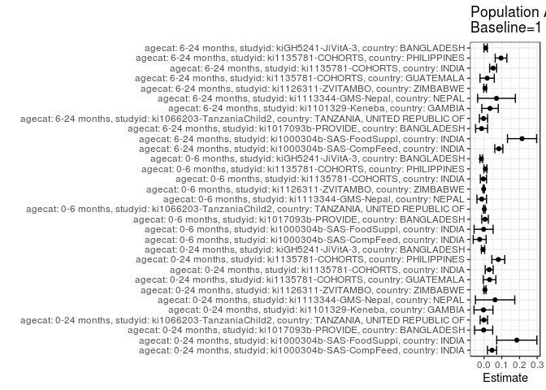

## Results Table

### Parameter: TSM

| agecat | studyid | country | intervention_level | baseline_level | estimate | ci_lower | ci_upper |
| --- | --- | --- | --- | --- | --- | --- | --- |
| 0-24 months | ki1000304b-SAS-CompFeed | INDIA | 1 | NA | 0.1865892 | 0.1301678 | 0.2430107 |
| 0-24 months | ki1000304b-SAS-CompFeed | INDIA | 2 | NA | 0.2221185 | 0.1587888 | 0.2854481 |
| 0-24 months | ki1000304b-SAS-CompFeed | INDIA | 3+ | NA | 0.2542407 | 0.2012202 | 0.3072612 |
| 0-24 months | ki1000304b-SAS-FoodSuppl | INDIA | 1 | NA | 0.1953808 | 0.0787026 | 0.3120589 |
| 0-24 months | ki1000304b-SAS-FoodSuppl | INDIA | 2 | NA | 0.4042238 | 0.2654922 | 0.5429553 |
| 0-24 months | ki1000304b-SAS-FoodSuppl | INDIA | 3+ | NA | 0.4004162 | 0.3277128 | 0.4731196 |
| 0-24 months | ki1017093b-PROVIDE | BANGLADESH | 1 | NA | 0.1305673 | 0.0736889 | 0.1874458 |
| 0-24 months | ki1017093b-PROVIDE | BANGLADESH | 2 | NA | 0.1267114 | 0.0616133 | 0.1918095 |
| 0-24 months | ki1017093b-PROVIDE | BANGLADESH | 3+ | NA | 0.0917814 | 0.0542725 | 0.1292904 |
| 0-24 months | ki1066203-TanzaniaChild2 | TANZANIA, UNITED REPUBLIC OF | 1 | NA | 0.0507918 | 0.0281311 | 0.0734526 |
| 0-24 months | ki1066203-TanzaniaChild2 | TANZANIA, UNITED REPUBLIC OF | 2 | NA | 0.0493878 | 0.0299957 | 0.0687799 |
| 0-24 months | ki1066203-TanzaniaChild2 | TANZANIA, UNITED REPUBLIC OF | 3+ | NA | 0.0591610 | 0.0390120 | 0.0793100 |
| 0-24 months | ki1101329-Keneba | GAMBIA | 1 | NA | 0.1678141 | 0.1142523 | 0.2213760 |
| 0-24 months | ki1101329-Keneba | GAMBIA | 2 | NA | 0.0838918 | 0.0357786 | 0.1320051 |
| 0-24 months | ki1101329-Keneba | GAMBIA | 3+ | NA | 0.1715628 | 0.1460028 | 0.1971228 |
| 0-24 months | ki1113344-GMS-Nepal | NEPAL | 1 | NA | 0.2581479 | 0.1429962 | 0.3732997 |
| 0-24 months | ki1113344-GMS-Nepal | NEPAL | 2 | NA | 0.2863106 | 0.1464270 | 0.4261942 |
| 0-24 months | ki1113344-GMS-Nepal | NEPAL | 3+ | NA | 0.2967865 | 0.2326270 | 0.3609460 |
| 0-24 months | ki1126311-ZVITAMBO | ZIMBABWE | 1 | NA | 0.0363989 | 0.0297263 | 0.0430715 |
| 0-24 months | ki1126311-ZVITAMBO | ZIMBABWE | 2 | NA | 0.0428693 | 0.0333281 | 0.0524105 |
| 0-24 months | ki1126311-ZVITAMBO | ZIMBABWE | 3+ | NA | 0.0585273 | 0.0467371 | 0.0703175 |
| 0-24 months | ki1135781-COHORTS | GUATEMALA | 1 | NA | 0.0789569 | 0.0413081 | 0.1166056 |
| 0-24 months | ki1135781-COHORTS | GUATEMALA | 2 | NA | 0.1175374 | 0.0698028 | 0.1652719 |
| 0-24 months | ki1135781-COHORTS | GUATEMALA | 3+ | NA | 0.1137294 | 0.0934551 | 0.1340038 |
| 0-24 months | ki1135781-COHORTS | INDIA | 1 | NA | 0.0713991 | 0.0484400 | 0.0943582 |
| 0-24 months | ki1135781-COHORTS | INDIA | 2 | NA | 0.0767208 | 0.0573793 | 0.0960623 |
| 0-24 months | ki1135781-COHORTS | INDIA | 3+ | NA | 0.1195856 | 0.1053999 | 0.1337714 |
| 0-24 months | ki1135781-COHORTS | PHILIPPINES | 1 | NA | 0.1032654 | 0.0664026 | 0.1401282 |
| 0-24 months | ki1135781-COHORTS | PHILIPPINES | 2 | NA | 0.1473035 | 0.1046171 | 0.1899899 |
| 0-24 months | ki1135781-COHORTS | PHILIPPINES | 3+ | NA | 0.2249029 | 0.1972434 | 0.2525623 |

[output cut: 63 more lines]

### Parameter: E(Y)

| agecat | studyid | country | intervention_level | baseline_level | estimate | ci_lower | ci_upper |
| --- | --- | --- | --- | --- | --- | --- | --- |
| 0-24 months | ki1000304b-SAS-CompFeed | INDIA | NA | NA | 0.2319894 | 0.1917264 | 0.2722524 |
| 0-24 months | ki1000304b-SAS-FoodSuppl | INDIA | NA | NA | 0.3803526 | 0.3325374 | 0.4281678 |
| 0-24 months | ki1017093b-PROVIDE | BANGLADESH | NA | NA | 0.1285714 | 0.1037574 | 0.1533855 |
| 0-24 months | ki1066203-TanzaniaChild2 | TANZANIA, UNITED REPUBLIC OF | NA | NA | 0.0500636 | 0.0412578 | 0.0588694 |
| 0-24 months | ki1101329-Keneba | GAMBIA | NA | NA | 0.1649899 | 0.1486698 | 0.1813101 |
| 0-24 months | ki1113344-GMS-Nepal | NEPAL | NA | NA | 0.3205980 | 0.2832855 | 0.3579105 |
| 0-24 months | ki1126311-ZVITAMBO | ZIMBABWE | NA | NA | 0.0417683 | 0.0384465 | 0.0450902 |
| 0-24 months | ki1135781-COHORTS | GUATEMALA | NA | NA | 0.1103654 | 0.0935883 | 0.1271425 |
| 0-24 months | ki1135781-COHORTS | INDIA | NA | NA | 0.1008003 | 0.0921209 | 0.1094798 |
| 0-24 months | ki1135781-COHORTS | PHILIPPINES | NA | NA | 0.1839080 | 0.1701456 | 0.1976705 |
| 0-24 months | kiGH5241-JiVitA-3 | BANGLADESH | NA | NA | 0.0885064 | 0.0846302 | 0.0923827 |
| 0-6 months | ki1000304b-SAS-CompFeed | INDIA | NA | NA | 0.0704787 | 0.0478990 | 0.0930584 |
| 0-6 months | ki1000304b-SAS-FoodSuppl | INDIA | NA | NA | 0.0757576 | 0.0496627 | 0.1018525 |
| 0-6 months | ki1017093b-PROVIDE | BANGLADESH | NA | NA | 0.0428571 | 0.0278427 | 0.0578716 |
| 0-6 months | ki1066203-TanzaniaChild2 | TANZANIA, UNITED REPUBLIC OF | NA | NA | 0.0080611 | 0.0044503 | 0.0116719 |
| 0-6 months | ki1113344-GMS-Nepal | NEPAL | NA | NA | 0.0398671 | 0.0242254 | 0.0555088 |
| 0-6 months | ki1126311-ZVITAMBO | ZIMBABWE | NA | NA | 0.0120673 | 0.0102481 | 0.0138865 |
| 0-6 months | ki1135781-COHORTS | INDIA | NA | NA | 0.0263336 | 0.0216247 | 0.0310424 |
| 0-6 months | ki1135781-COHORTS | PHILIPPINES | NA | NA | 0.0236531 | 0.0182537 | 0.0290525 |
| 0-6 months | kiGH5241-JiVitA-3 | BANGLADESH | NA | NA | 0.0393357 | 0.0368510 | 0.0418204 |
| 6-24 months | ki1000304b-SAS-CompFeed | INDIA | NA | NA | 0.2260619 | 0.1909133 | 0.2612105 |
| 6-24 months | ki1000304b-SAS-FoodSuppl | INDIA | NA | NA | 0.3578680 | 0.3104738 | 0.4052622 |
| 6-24 months | ki1017093b-PROVIDE | BANGLADESH | NA | NA | 0.1221498 | 0.0962275 | 0.1480722 |
| 6-24 months | ki1066203-TanzaniaChild2 | TANZANIA, UNITED REPUBLIC OF | NA | NA | 0.0563948 | 0.0462467 | 0.0665428 |
| 6-24 months | ki1101329-Keneba | GAMBIA | NA | NA | 0.1612064 | 0.1447669 | 0.1776460 |
| 6-24 months | ki1113344-GMS-Nepal | NEPAL | NA | NA | 0.3220339 | 0.2842988 | 0.3597690 |
| 6-24 months | ki1126311-ZVITAMBO | ZIMBABWE | NA | NA | 0.0406846 | 0.0369398 | 0.0444295 |
| 6-24 months | ki1135781-COHORTS | GUATEMALA | NA | NA | 0.1123039 | 0.0945135 | 0.1300943 |
| 6-24 months | ki1135781-COHORTS | INDIA | NA | NA | 0.0965883 | 0.0877969 | 0.1053797 |
| 6-24 months | ki1135781-COHORTS | PHILIPPINES | NA | NA | 0.1908832 | 0.1763448 | 0.2054216 |
| 6-24 months | kiGH5241-JiVitA-3 | BANGLADESH | NA | NA | 0.0867929 | 0.0821342 | 0.0914516 |

### Parameter: RR

| agecat | studyid | country | intervention_level | baseline_level | estimate | ci_lower | ci_upper |
| --- | --- | --- | --- | --- | --- | --- | --- |
| 0-24 months | ki1000304b-SAS-CompFeed | INDIA | 1 | 1 | 1.0000000 | 1.0000000 | 1.0000000 |
| 0-24 months | ki1000304b-SAS-CompFeed | INDIA | 2 | 1 | 1.1904142 | 0.9814029 | 1.4439390 |
| 0-24 months | ki1000304b-SAS-CompFeed | INDIA | 3+ | 1 | 1.3625690 | 1.1014228 | 1.6856326 |
| 0-24 months | ki1000304b-SAS-FoodSuppl | INDIA | 1 | 1 | 1.0000000 | 1.0000000 | 1.0000000 |
| 0-24 months | ki1000304b-SAS-FoodSuppl | INDIA | 2 | 1 | 2.0689023 | 1.0393769 | 4.1181950 |
| 0-24 months | ki1000304b-SAS-FoodSuppl | INDIA | 3+ | 1 | 2.0494144 | 1.0987551 | 3.8225983 |
| 0-24 months | ki1017093b-PROVIDE | BANGLADESH | 1 | 1 | 1.0000000 | 1.0000000 | 1.0000000 |
| 0-24 months | ki1017093b-PROVIDE | BANGLADESH | 2 | 1 | 0.9704678 | 0.4951119 | 1.9022117 |
| 0-24 months | ki1017093b-PROVIDE | BANGLADESH | 3+ | 1 | 0.7029431 | 0.3869716 | 1.2769131 |
| 0-24 months | ki1066203-TanzaniaChild2 | TANZANIA, UNITED REPUBLIC OF | 1 | 1 | 1.0000000 | 1.0000000 | 1.0000000 |
| 0-24 months | ki1066203-TanzaniaChild2 | TANZANIA, UNITED REPUBLIC OF | 2 | 1 | 0.9723572 | 0.5366640 | 1.7617700 |
| 0-24 months | ki1066203-TanzaniaChild2 | TANZANIA, UNITED REPUBLIC OF | 3+ | 1 | 1.1647733 | 0.6643850 | 2.0420341 |
| 0-24 months | ki1101329-Keneba | GAMBIA | 1 | 1 | 1.0000000 | 1.0000000 | 1.0000000 |
| 0-24 months | ki1101329-Keneba | GAMBIA | 2 | 1 | 0.4999091 | 0.2592787 | 0.9638629 |
| 0-24 months | ki1101329-Keneba | GAMBIA | 3+ | 1 | 1.0223380 | 0.7197401 | 1.4521561 |
| 0-24 months | ki1113344-GMS-Nepal | NEPAL | 1 | 1 | 1.0000000 | 1.0000000 | 1.0000000 |
| 0-24 months | ki1113344-GMS-Nepal | NEPAL | 2 | 1 | 1.1090951 | 0.5721480 | 2.1499538 |
| 0-24 months | ki1113344-GMS-Nepal | NEPAL | 3+ | 1 | 1.1496761 | 0.7002067 | 1.8876642 |
| 0-24 months | ki1126311-ZVITAMBO | ZIMBABWE | 1 | 1 | 1.0000000 | 1.0000000 | 1.0000000 |
| 0-24 months | ki1126311-ZVITAMBO | ZIMBABWE | 2 | 1 | 1.1777644 | 0.8827695 | 1.5713377 |
| 0-24 months | ki1126311-ZVITAMBO | ZIMBABWE | 3+ | 1 | 1.6079428 | 1.2245157 | 2.1114307 |
| 0-24 months | ki1135781-COHORTS | GUATEMALA | 1 | 1 | 1.0000000 | 1.0000000 | 1.0000000 |
| 0-24 months | ki1135781-COHORTS | GUATEMALA | 2 | 1 | 1.4886275 | 0.7960992 | 2.7835875 |
| 0-24 months | ki1135781-COHORTS | GUATEMALA | 3+ | 1 | 1.4403994 | 0.8656521 | 2.3967485 |
| 0-24 months | ki1135781-COHORTS | INDIA | 1 | 1 | 1.0000000 | 1.0000000 | 1.0000000 |
| 0-24 months | ki1135781-COHORTS | INDIA | 2 | 1 | 1.0745344 | 0.7144716 | 1.6160531 |
| 0-24 months | ki1135781-COHORTS | INDIA | 3+ | 1 | 1.6748897 | 1.1893611 | 2.3586238 |
| 0-24 months | ki1135781-COHORTS | PHILIPPINES | 1 | 1 | 1.0000000 | 1.0000000 | 1.0000000 |
| 0-24 months | ki1135781-COHORTS | PHILIPPINES | 2 | 1 | 1.4264547 | 0.9010630 | 2.2581916 |
| 0-24 months | ki1135781-COHORTS | PHILIPPINES | 3+ | 1 | 2.1779105 | 1.4930733 | 3.1768662 |

[output cut: 63 more lines]

### Parameter: PAR

| agecat | studyid | country | intervention_level | baseline_level | estimate | ci_lower | ci_upper |
| --- | --- | --- | --- | --- | --- | --- | --- |
| 0-24 months | ki1000304b-SAS-CompFeed | INDIA | 1 | NA | 0.0454002 | 0.0197287 | 0.0710717 |
| 0-24 months | ki1000304b-SAS-FoodSuppl | INDIA | 1 | NA | 0.1849719 | 0.0717909 | 0.2981528 |
| 0-24 months | ki1017093b-PROVIDE | BANGLADESH | 1 | NA | -0.0019959 | -0.0531173 | 0.0491255 |
| 0-24 months | ki1066203-TanzaniaChild2 | TANZANIA, UNITED REPUBLIC OF | 1 | NA | -0.0007282 | -0.0215848 | 0.0201285 |
| 0-24 months | ki1101329-Keneba | GAMBIA | 1 | NA | -0.0028242 | -0.0562350 | 0.0505866 |
| 0-24 months | ki1113344-GMS-Nepal | NEPAL | 1 | NA | 0.0624501 | -0.0484168 | 0.1733169 |
| 0-24 months | ki1126311-ZVITAMBO | ZIMBABWE | 1 | NA | 0.0053695 | -0.0006754 | 0.0114143 |
| 0-24 months | ki1135781-COHORTS | GUATEMALA | 1 | NA | 0.0314085 | -0.0041566 | 0.0669736 |
| 0-24 months | ki1135781-COHORTS | INDIA | 1 | NA | 0.0294012 | 0.0070007 | 0.0518018 |
| 0-24 months | ki1135781-COHORTS | PHILIPPINES | 1 | NA | 0.0806426 | 0.0443116 | 0.1169736 |
| 0-24 months | kiGH5241-JiVitA-3 | BANGLADESH | 1 | NA | -0.0054852 | -0.0147068 | 0.0037365 |
| 0-6 months | ki1000304b-SAS-CompFeed | INDIA | 1 | NA | -0.0242966 | -0.0606613 | 0.0120681 |
| 0-6 months | ki1000304b-SAS-FoodSuppl | INDIA | 1 | NA | -0.0021645 | -0.0558026 | 0.0514736 |
| 0-6 months | ki1017093b-PROVIDE | BANGLADESH | 1 | NA | 0.0059568 | -0.0124634 | 0.0243770 |
| 0-6 months | ki1066203-TanzaniaChild2 | TANZANIA, UNITED REPUBLIC OF | 1 | NA | 0.0019710 | -0.0026802 | 0.0066221 |
| 0-6 months | ki1113344-GMS-Nepal | NEPAL | 1 | NA | -0.0127645 | -0.0397689 | 0.0142400 |
| 0-6 months | ki1126311-ZVITAMBO | ZIMBABWE | 1 | NA | -0.0015047 | -0.0049509 | 0.0019416 |
| 0-6 months | ki1135781-COHORTS | INDIA | 1 | NA | -0.0032387 | -0.0207968 | 0.0143194 |
| 0-6 months | ki1135781-COHORTS | PHILIPPINES | 1 | NA | 0.0079177 | -0.0006017 | 0.0164372 |
| 0-6 months | kiGH5241-JiVitA-3 | BANGLADESH | 1 | NA | -0.0152040 | -0.0229476 | -0.0074604 |
| 6-24 months | ki1000304b-SAS-CompFeed | INDIA | 1 | NA | 0.0835388 | 0.0607939 | 0.1062837 |
| 6-24 months | ki1000304b-SAS-FoodSuppl | INDIA | 1 | NA | 0.2146455 | 0.1324370 | 0.2968540 |
| 6-24 months | ki1017093b-PROVIDE | BANGLADESH | 1 | NA | -0.0135701 | -0.0472669 | 0.0201267 |
| 6-24 months | ki1066203-TanzaniaChild2 | TANZANIA, UNITED REPUBLIC OF | 1 | NA | -0.0027707 | -0.0258642 | 0.0203229 |
| 6-24 months | ki1101329-Keneba | GAMBIA | 1 | NA | 0.0340240 | -0.0123859 | 0.0804339 |
| 6-24 months | ki1113344-GMS-Nepal | NEPAL | 1 | NA | 0.0703533 | -0.0358747 | 0.1765814 |
| 6-24 months | ki1126311-ZVITAMBO | ZIMBABWE | 1 | NA | 0.0061128 | -0.0014027 | 0.0136283 |
| 6-24 months | ki1135781-COHORTS | GUATEMALA | 1 | NA | 0.0177493 | -0.0224435 | 0.0579421 |
| 6-24 months | ki1135781-COHORTS | INDIA | 1 | NA | 0.0516063 | 0.0317230 | 0.0714895 |
| 6-24 months | ki1135781-COHORTS | PHILIPPINES | 1 | NA | 0.0959584 | 0.0630104 | 0.1289064 |
| 6-24 months | kiGH5241-JiVitA-3 | BANGLADESH | 1 | NA | 0.0091686 | -0.0000024 | 0.0183396 |

### Parameter: PAF

| agecat | studyid | country | intervention_level | baseline_level | estimate | ci_lower | ci_upper |
| --- | --- | --- | --- | --- | --- | --- | --- |
| 0-24 months | ki1000304b-SAS-CompFeed | INDIA | 1 | NA | 0.1956994 | 0.0555862 | 0.3150254 |
| 0-24 months | ki1000304b-SAS-FoodSuppl | INDIA | 1 | NA | 0.4863167 | 0.0869400 | 0.7110042 |
| 0-24 months | ki1017093b-PROVIDE | BANGLADESH | 1 | NA | -0.0155238 | -0.5022160 | 0.3134885 |
| 0-24 months | ki1066203-TanzaniaChild2 | TANZANIA, UNITED REPUBLIC OF | 1 | NA | -0.0145451 | -0.5297001 | 0.3271218 |
| 0-24 months | ki1101329-Keneba | GAMBIA | 1 | NA | -0.0171174 | -0.3986245 | 0.2603248 |
| 0-24 months | ki1113344-GMS-Nepal | NEPAL | 1 | NA | 0.1947924 | -0.2365132 | 0.4756552 |
| 0-24 months | ki1126311-ZVITAMBO | ZIMBABWE | 1 | NA | 0.1285534 | -0.0283889 | 0.2615448 |
| 0-24 months | ki1135781-COHORTS | GUATEMALA | 1 | NA | 0.2845868 | -0.1197009 | 0.5428993 |
| 0-24 months | ki1135781-COHORTS | INDIA | 1 | NA | 0.2916781 | 0.0331244 | 0.4810915 |
| 0-24 months | ki1135781-COHORTS | PHILIPPINES | 1 | NA | 0.4384942 | 0.2048898 | 0.6034653 |
| 0-24 months | kiGH5241-JiVitA-3 | BANGLADESH | 1 | NA | -0.0619747 | -0.1714232 | 0.0372478 |
| 0-6 months | ki1000304b-SAS-CompFeed | INDIA | 1 | NA | -0.3447369 | -1.0051084 | 0.0981448 |
| 0-6 months | ki1000304b-SAS-FoodSuppl | INDIA | 1 | NA | -0.0285714 | -1.0471955 | 0.4832154 |
| 0-6 months | ki1017093b-PROVIDE | BANGLADESH | 1 | NA | 0.1389914 | -0.4142101 | 0.4757951 |
| 0-6 months | ki1066203-TanzaniaChild2 | TANZANIA, UNITED REPUBLIC OF | 1 | NA | 0.2445028 | -0.5993898 | 0.6431289 |
| 0-6 months | ki1113344-GMS-Nepal | NEPAL | 1 | NA | -0.3201754 | -1.1878788 | 0.2034005 |
| 0-6 months | ki1126311-ZVITAMBO | ZIMBABWE | 1 | NA | -0.1246884 | -0.4495338 | 0.1273581 |
| 0-6 months | ki1135781-COHORTS | INDIA | 1 | NA | -0.1229869 | -1.0330755 | 0.3797085 |
| 0-6 months | ki1135781-COHORTS | PHILIPPINES | 1 | NA | 0.3347447 | -0.1277609 | 0.6075724 |
| 0-6 months | kiGH5241-JiVitA-3 | BANGLADESH | 1 | NA | -0.3865200 | -0.5984255 | -0.2027072 |
| 6-24 months | ki1000304b-SAS-CompFeed | INDIA | 1 | NA | 0.3695394 | 0.2204433 | 0.4901198 |
| 6-24 months | ki1000304b-SAS-FoodSuppl | INDIA | 1 | NA | 0.5997895 | 0.3066908 | 0.7689798 |
| 6-24 months | ki1017093b-PROVIDE | BANGLADESH | 1 | NA | -0.1110937 | -0.4228635 | 0.1323629 |
| 6-24 months | ki1066203-TanzaniaChild2 | TANZANIA, UNITED REPUBLIC OF | 1 | NA | -0.0491298 | -0.5499701 | 0.2898745 |
| 6-24 months | ki1101329-Keneba | GAMBIA | 1 | NA | 0.2110586 | -0.1310381 | 0.4496838 |
| 6-24 months | ki1113344-GMS-Nepal | NEPAL | 1 | NA | 0.2184656 | -0.1905035 | 0.4869432 |
| 6-24 months | ki1126311-ZVITAMBO | ZIMBABWE | 1 | NA | 0.1502491 | -0.0553274 | 0.3157795 |
| 6-24 months | ki1135781-COHORTS | GUATEMALA | 1 | NA | 0.1580471 | -0.2869408 | 0.4491707 |
| 6-24 months | ki1135781-COHORTS | INDIA | 1 | NA | 0.5342911 | 0.2837000 | 0.6972152 |
| 6-24 months | ki1135781-COHORTS | PHILIPPINES | 1 | NA | 0.5027074 | 0.3011417 | 0.6461373 |
| 6-24 months | kiGH5241-JiVitA-3 | BANGLADESH | 1 | NA | 0.1056377 | -0.0063883 | 0.2051936 |